# B620_HW2

#### Questions

1. What is the association between BMI and FEV (forced expiratory volume)?
   - The correlation is 0.357 indicating a weak positive association between BMI and FEV. This weak association also can be observed in the scatter plot.
2. What is the association between smoke and gas exposure and FEV?
   - There is no association between smoke and gas exposure and FEV. The box size and line position in the box plot are very similar over categories.
3. What is the association between PM2.5 exposure and FEV?
   - There is no association between PM2.5 exposure and FEV. The mean line does not have significant slop indicating no association.

```r
# EDA check
summary(merged[c("bmi", "fev", "smoke_gas_exposure", "pm25_mass")])
```

```
      bmi             fev         smoke_gas_exposure   pm25_mass
 Min.   :11.30   Min.   : 984.8   Length:1200        Min.   : 5.960
 1st Qu.:15.96   1st Qu.:1827.6   Class :character   1st Qu.: 7.615
 Median :17.81   Median :2016.4   Mode  :character   Median :10.545
 Mean   :18.50   Mean   :2030.1                      Mean   :14.362
 3rd Qu.:19.99   3rd Qu.:2223.6                      3rd Qu.:20.988
 Max.   :41.27   Max.   :3323.7                      Max.   :29.970
```

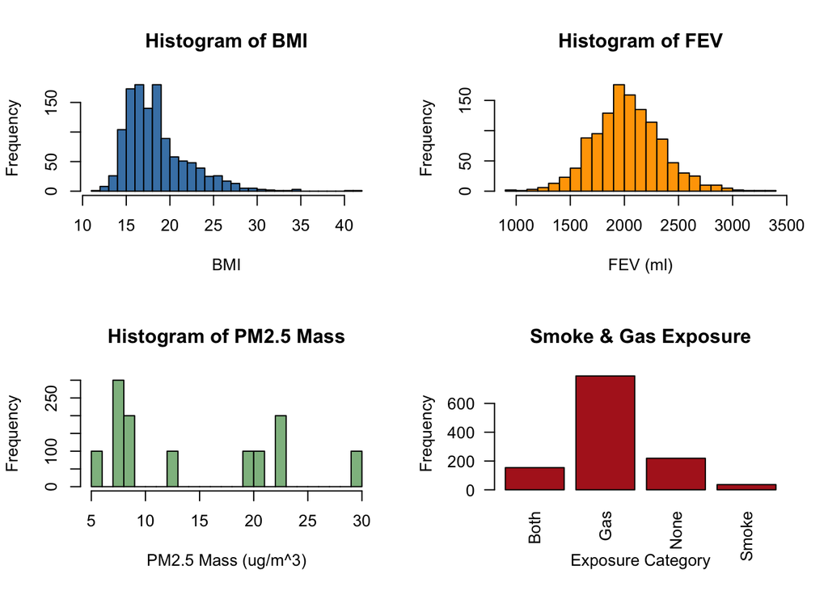

```r
par(mfrow = c(2, 2))
# BMI
hist(merged$bmi,
     breaks = 30,
     col = "steelblue",
     border = "black",
     main = "Histogram of BMI",
     xlab = "BMI",
     ylab = "Frequency")

# FEV
hist(merged$fev,
     breaks = 30,
     col = "orange",
     border = "black",
     main = "Histogram of FEV",
     xlab = "FEV (ml)",
     ylab = "Frequency")

# PM2.5
hist(merged$pm25_mass,
     breaks = 30,
     col = "darkseagreen",
     border = "black",
     main = "Histogram of PM2.5 Mass",
     xlab = "PM2.5 Mass (ug/m^3)",
     ylab = "Frequency")

# smoke_gas_exposure
barplot(table(merged$smoke_gas_exposure),
        col = "firebrick",
        border = "black",
        main = "Smoke & Gas Exposure",
        xlab = "Exposure Category",
        ylab = "Frequency",
        las = 2)
```

```r
par(mfrow = c(1, 1))

# Questions
# 1. What is the association between BMI and FEV
cor(merged$bmi, merged$fev)
```

```
[1] 0.357112
```

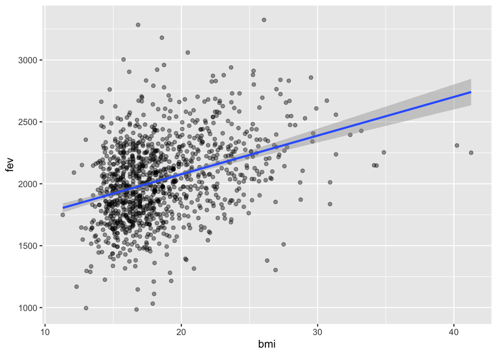

```r
ggplot(merged, aes(x = bmi, y = fev)) +
  geom_point(alpha = 0.4) +
  geom_smooth(method = "lm")
```

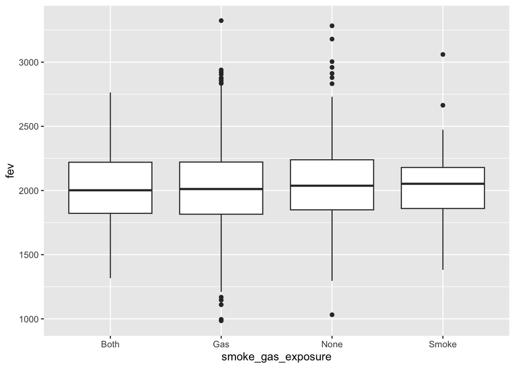

```r
# 2. What is the association between smoke and gas exposure and FEV?
ggplot(merged, aes(x = smoke_gas_exposure, y = fev)) +
  geom_boxplot()
```

```r
# 3. What is the association between PM2.5 exposure and FEV?
cor(merged$pm25_mass, merged$fev)
```

```
[1] -0.07341317
```

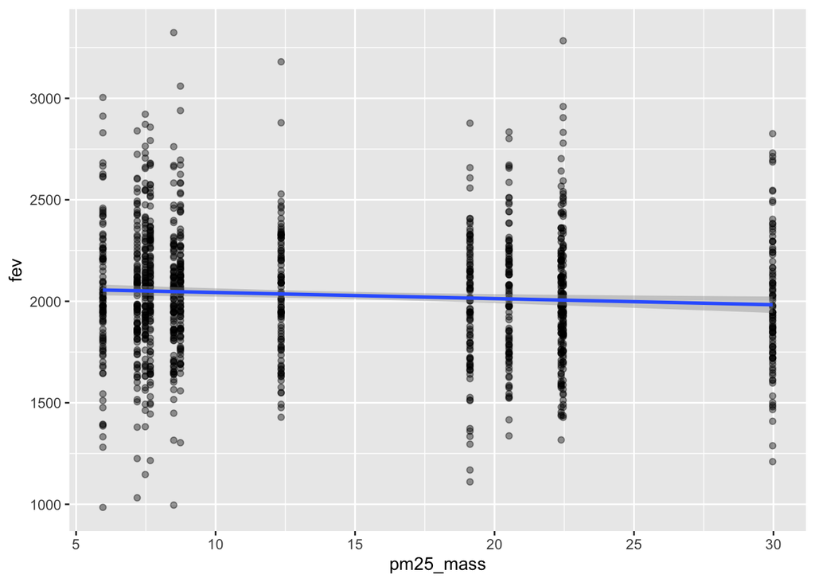

```r
ggplot(merged, aes(x = pm25_mass, y = fev)) +
  geom_point(alpha = 0.4) +
  geom_smooth(method = "lm")
```

### Visualization (30 points)

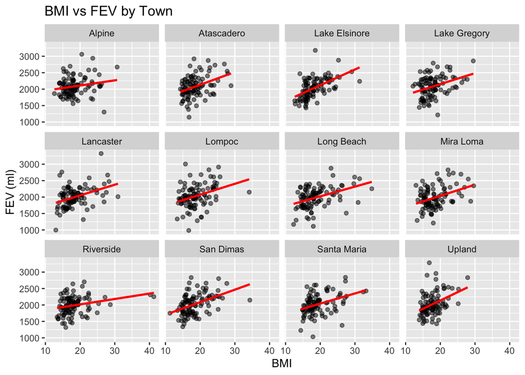

```r
# 1. Facet plot showing scatterplots with regression lines of BMI vs FEV by “townname”.
ggplot(merged, aes(x = bmi, y = fev)) +
  geom_point(alpha = 0.5) +
  geom_smooth(method = "lm", se = FALSE, color = "red") +
  facet_wrap(~ townname) +
  labs(title = "BMI vs FEV by Town",
       x = "BMI",
       y = "FEV (ml)")
```

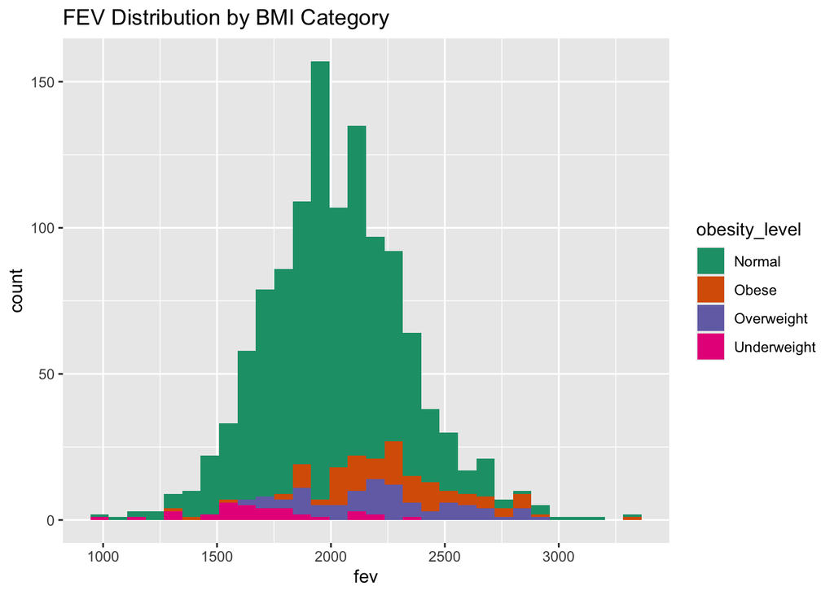

```r
# 2. Stacked histograms of (1) FEV by BMI category and (2) FEV by smoke/gas exposure. Use different color schemes than the ggplot default.
# (1) FEV by BMI category
ggplot(merged, aes(x = fev, fill = obesity_level)) +
  geom_histogram(position = "stack", bins = 30) +
  scale_fill_brewer(palette = "Dark2") +
  labs(title = "FEV Distribution by BMI Category")
```

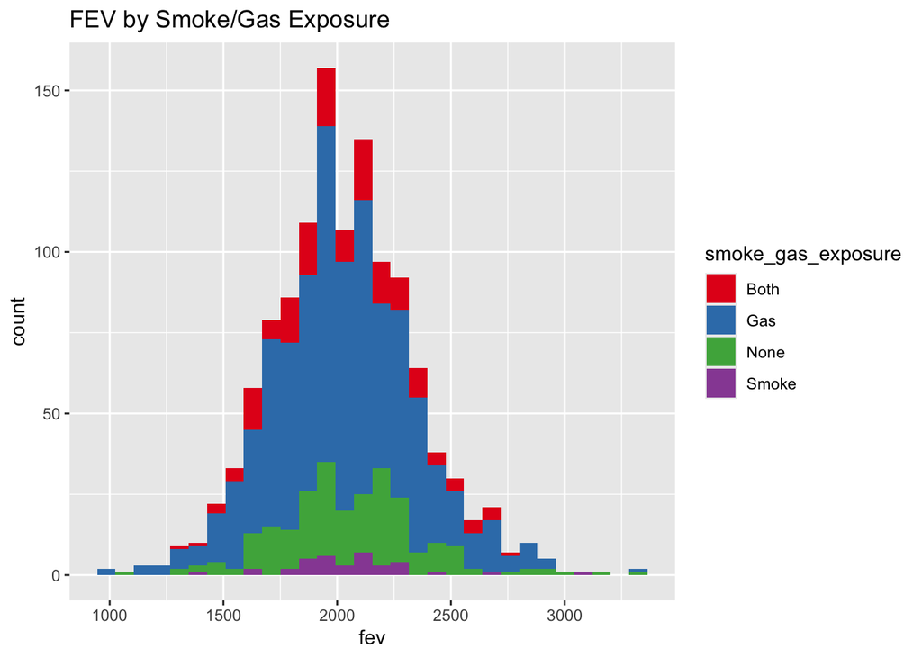

```r
# (2) FEV by smoke/gas exposure
ggplot(merged, aes(x = fev, fill = smoke_gas_exposure)) +
  geom_histogram(position = "stack", bins = 30) +
  scale_fill_brewer(palette = "Set1") +
  labs(title = "FEV by Smoke/Gas Exposure")
```